# nirmitin_OriginalHomeworkCode_03

Nirmiti Naik

10/6/2021

The curl and ggplot package is installed

```r
library(curl)
```

```r
library(ggplot2)
```

The zombies.csv file is loaded

```r
f <- f <- curl("https://raw.githubusercontent.com/fuzzyatelin/fuzzyatelin.github.io/master/AN588_Fall21/zombies.csv")
d <- read.csv(f, header = TRUE, sep = ",", stringsAsFactors = FALSE)
head(d)
```

```
##   id first_name last_name gender   height   weight zombies_killed
## 1  1      Sarah    Little Female 62.88951 132.0872              2
## 2  2       Mark    Duncan   Male 67.80277 146.3753              5
## 3  3    Brandon     Perez   Male 72.12908 152.9370              1
## 4  4      Roger   Coleman   Male 66.78484 129.7418              5
## 5  5      Tammy    Powell Female 64.71832 132.4265              4
## 6  6    Anthony     Green   Male 71.24326 152.5246              1
##   years_of_education                           major      age
## 1                  1                medicine/nursing 17.64275
## 2                  3 criminal justice administration 22.58951
## 3                  1                       education 21.91276
## 4                  6                  energy studies 18.19058
## 5                  3                       logistics 21.10399
## 6                  4                  energy studies 21.48355
```

## **Question 1**

*Calculate the population mean and standard deviation for each quantitative random variable (height, weight, age, number of zombies killed, and years of education). NOTE: You will not want to use the built in var() and sd() commands as these are for samples.* First, I calculated the population mean for each quantitative variable

```r
height <- d[5]
weight <- d[6]
age <- d[10]
zombieskilled <- d[7]
education <- d[8]
mean(d$height)
```

```
## [1] 67.6301
```

```r
mean(d$weight)
```

```
## [1] 143.9075
```

```r
mean(d$age)
```

```
## [1] 20.04696
```

```r
mean(d$zombies_killed)
```

```
## [1] 2.992
```

```r
mean(d$years_of_education)
```

```
## [1] 2.996
```

Next, I calculated the population standard devaiations for each quantitative variable.

```r
height <- d[5]
weight <- d[6]
age <- d[10]
zombies_killed <- d[7]
years_of_education <- d[8]
sigma_height <- sqrt(sum((height - mean(height))^2)/length(height))
sigma_weight <- sqrt(sum((weight - mean(weight))^2)/length(weight))
sigma_age <- sqrt(sum((age - mean(age))^2)/length(age))
sigma_zombieskilled <- sqrt(sum((zombies_killed - mean(zombies_killed))^2)/length(zombies_killed))
sigma_education <- sqrt(sum((years_of_education - mean(years_of_education))^2)/length(years_of_education))
```

## **Question 2**

*Use {ggplot} and make boxplots of each of these variables by gender.* #### Gender x Height

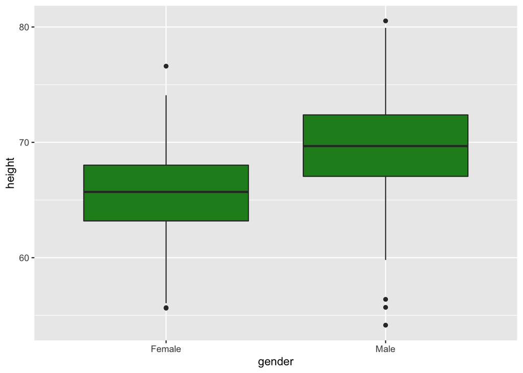

```r
f <- ggplot(data = d, aes(x = gender, y = height)) + geom_boxplot(fill = 'forestgreen')
f
```

#### Gender x Weight

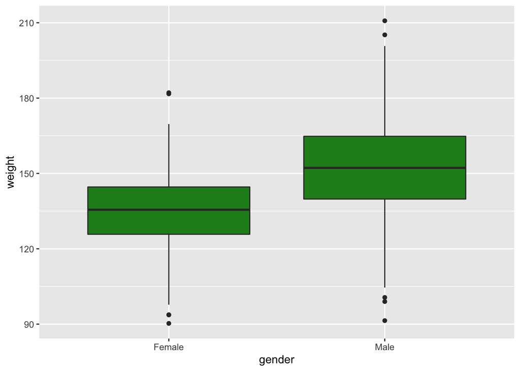

```r
f <- ggplot(data = d, aes(x = gender, y = weight)) + geom_boxplot(fill = 'forestgreen')
f
```

#### Gender x Age

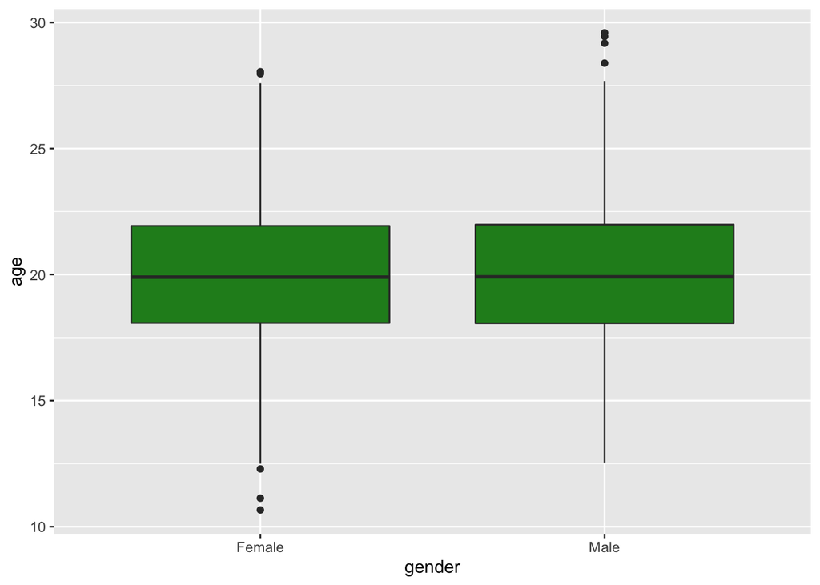

```r
f <- ggplot(data = d, aes(x = gender, y = age)) + geom_boxplot(fill = 'forestgreen')
f
```

#### Gender x # of Zombies Killed

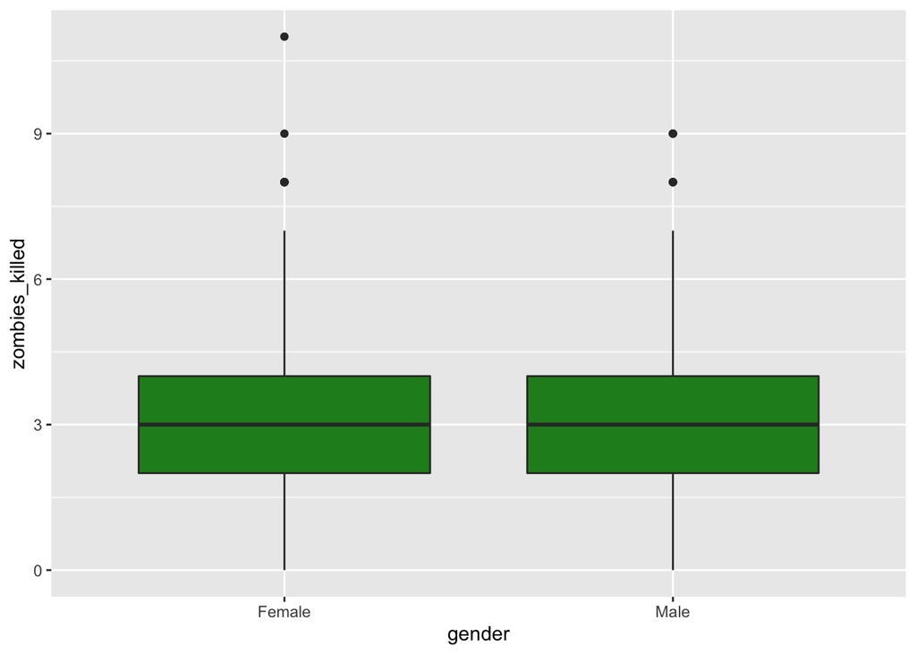

```r
f <- ggplot(data = d, aes(x = gender, y = zombies_killed)) + geom_boxplot(fill = 'forestgreen')
f
```

#### Gender x Years of Education

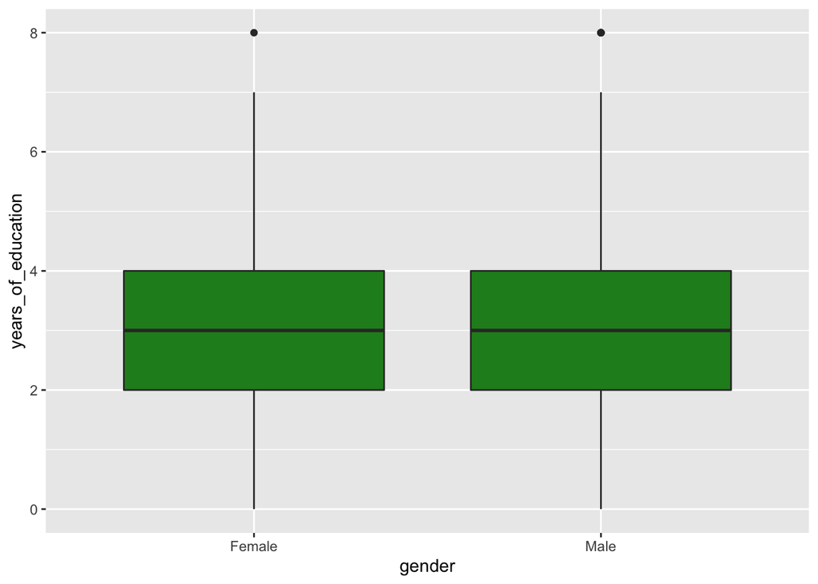

```r
f <- ggplot(data = d, aes(x = gender, y = years_of_education)) + geom_boxplot(fill = 'forestgreen')
f
```

## **Question 3**

*Use {ggplot} and make scatterplots of height and weight in relation to age. Do these variables seem to be related? In what way?*

Based on the below scatterplots, height and weight seem to be positively related to age since as age increases, so do height and weight. #### Age x Height

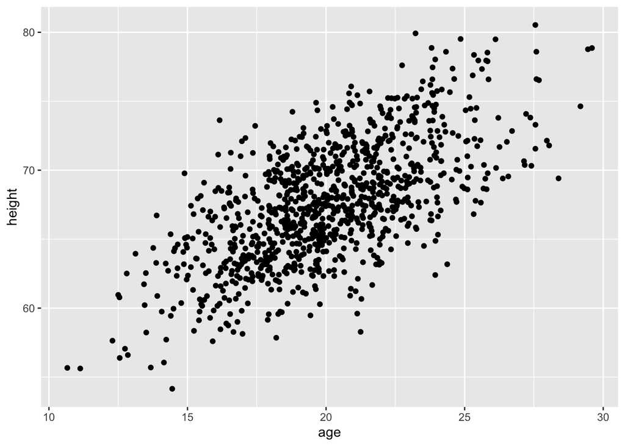

```r
e <- ggplot(data = d, aes(x = age, y = height)) + geom_point(fill = 'forestgreen')
e
```

#### Age x Weight

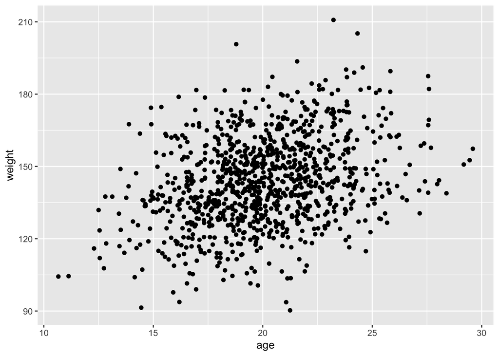

```r
e <- ggplot(data = d, aes(x = age, y = weight)) + geom_point(fill = 'forestgreen')
e
```

## **Question 4**

*Using histograms and Q-Q plots, check whether the quantitative variables seem to be drawn from a normal distribution. Which seem to be and which do not (hint: not all are drawn from the normal distribution)? For those that are not, can you determine what common distribution they are drawn from?*

#### Height:

Height seems to be drawn from a normal distribution because the majority of the data points for height fall along the qqline which is a measure of normality. Additionally, the histogram’s shape is similar to that of a normally distributed curve.

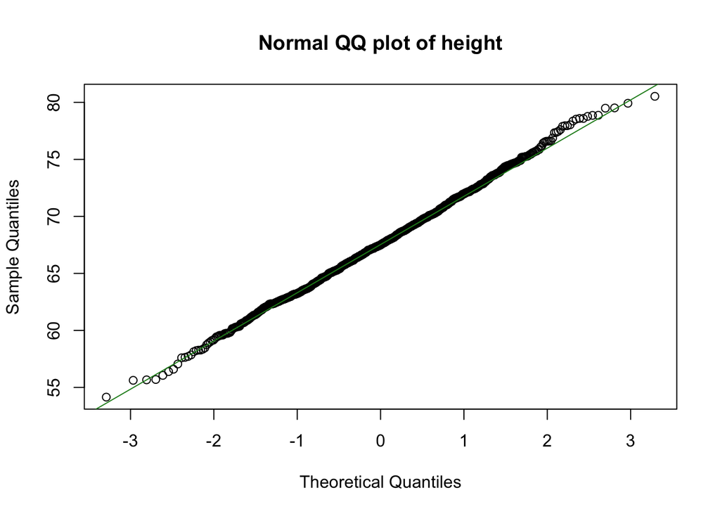

```r
qqnorm(d$height, main = "Normal QQ plot of height")
qqline(d$height, col = 'forestgreen')
```

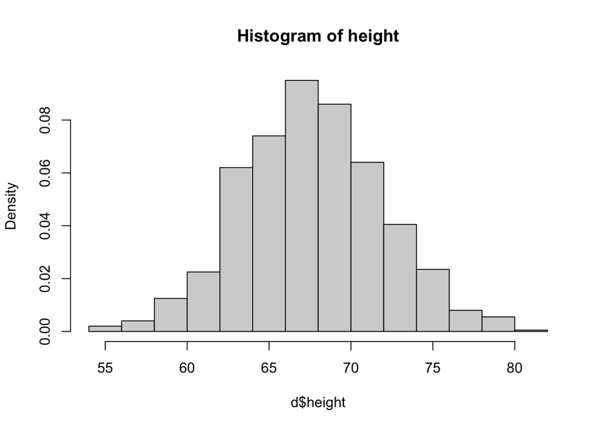

```r
hist(d$height, probability = TRUE, main = 'Histogram of height')
```

#### Weight:

Weight seems to be drawn from a normal distribution because the majority of the data points for height fall along the qqline which is a measure of normality. Additionally, the histogram’s shape is similar to that of a normally distributed curve.

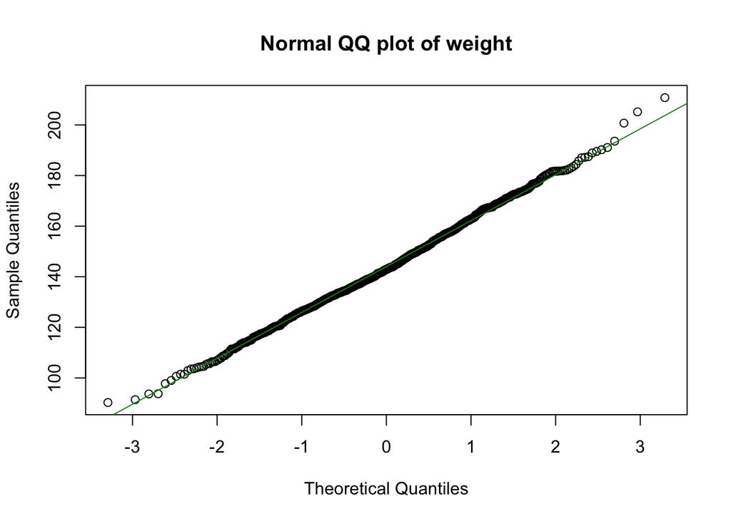

```r
qqnorm(d$weight, main = "Normal QQ plot of weight")
qqline(d$weight, col = 'forestgreen')
```

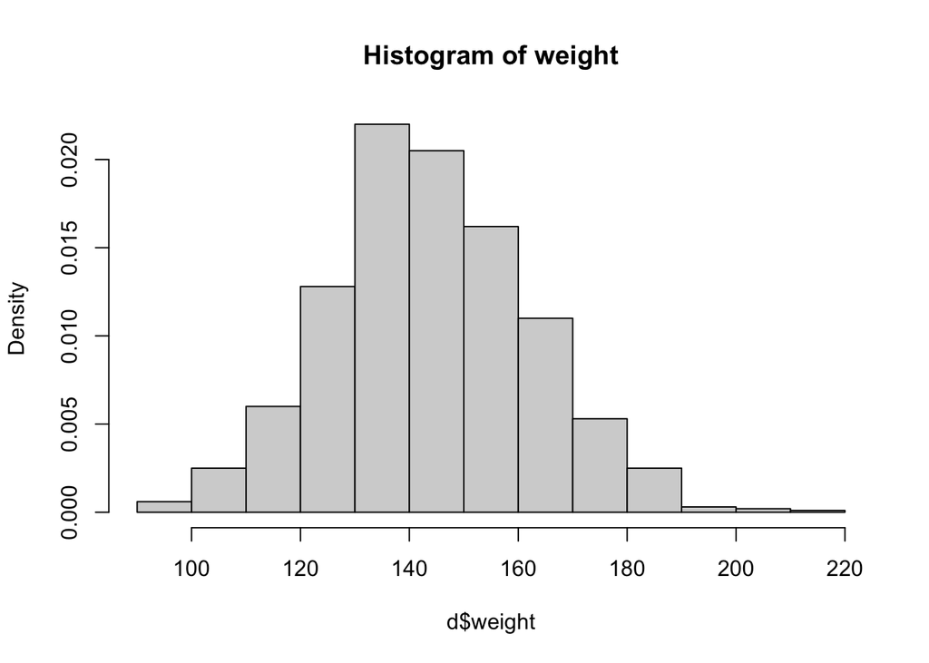

```r
hist(d$weight, probability = TRUE, main = 'Histogram of weight')
```

#### Age:

Age seems to be drawn from a normal distribution because the majority of the data points for height fall along the qqline which is a measure of normality. Additionally, the histogram’s shape is similar to that of a normally distributed curve.

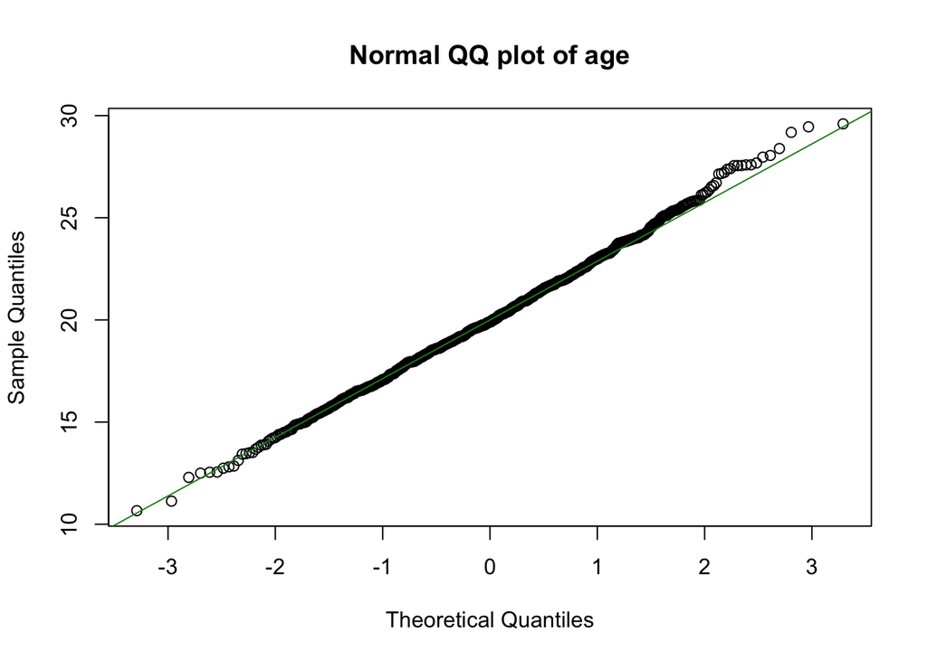

```r
qqnorm(d$age, main = "Normal QQ plot of age")
qqline(d$age, col = 'forestgreen')
```

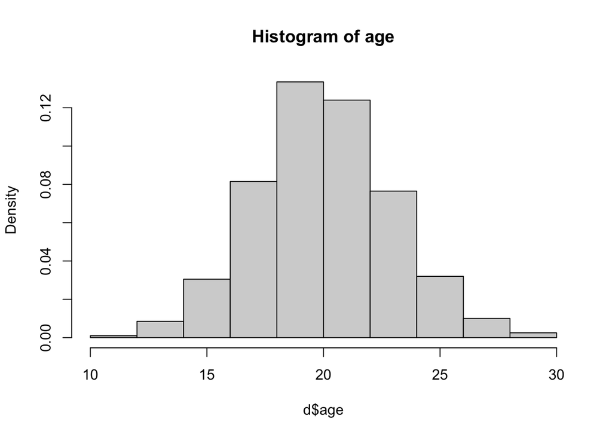

```r
hist(d$age, probability = TRUE, main = 'Histogram of age')
```

#### # of Zombies Killed:

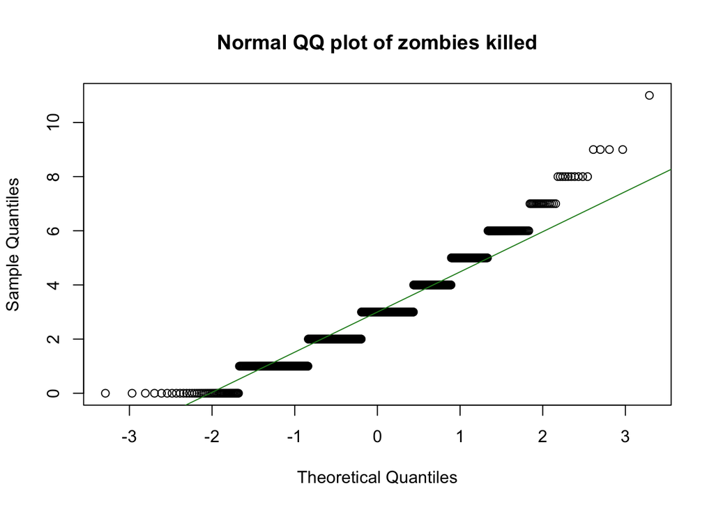

```r
qqnorm(d$zombies_killed, main = "Normal QQ plot of zombies killed")
qqline(d$zombies_killed, col = 'forestgreen')
```

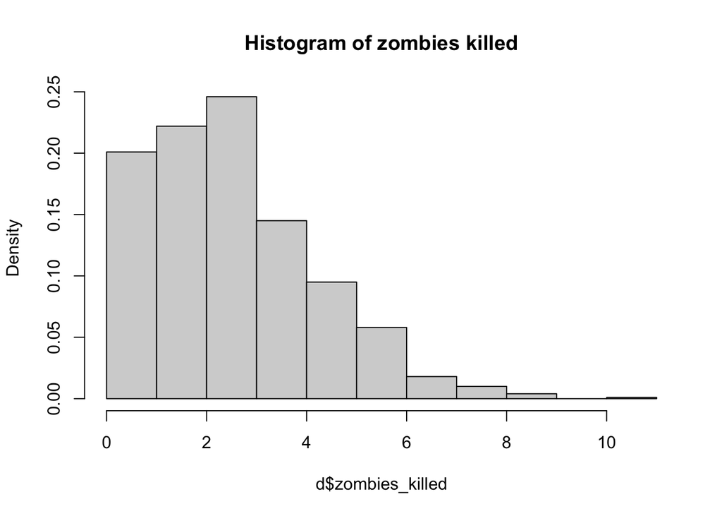

```r
hist(d$zombies_killed, probability = TRUE, main = 'Histogram of zombies killed')
```

#### Years of Education:

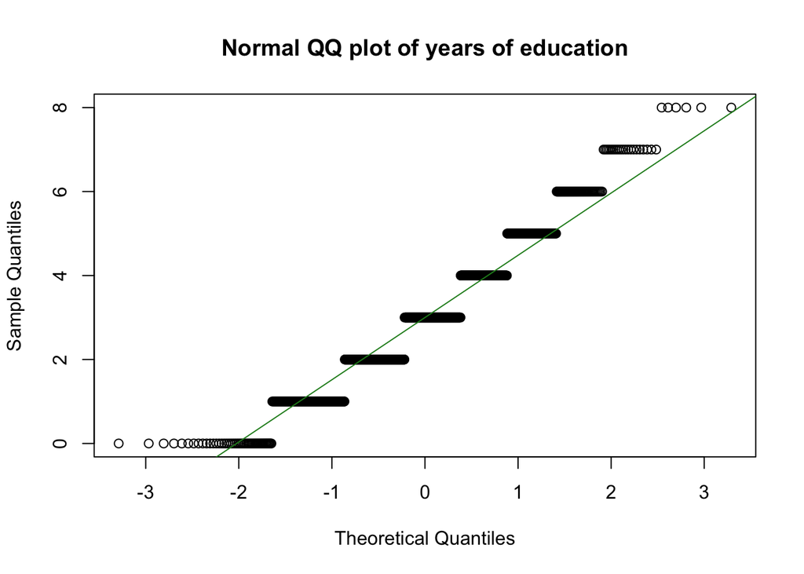

```r
qqnorm(d$years_of_education, main = "Normal QQ plot of years of education")
qqline(d$years_of_education, col = 'forestgreen')
```

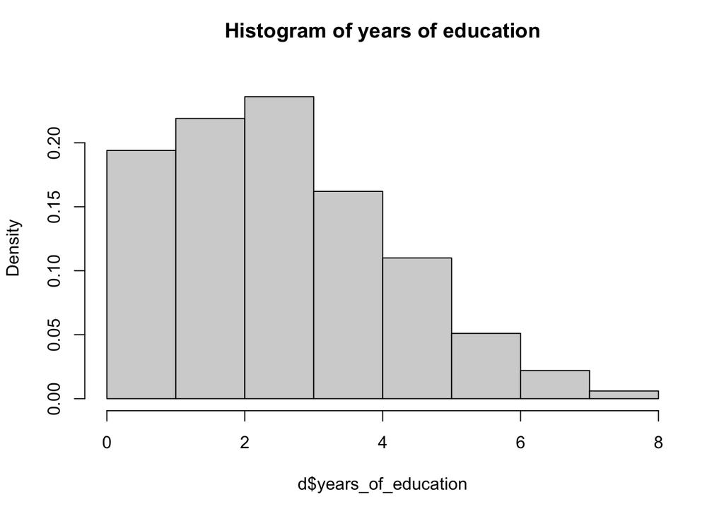

```r
hist(d$years_of_education, probability = TRUE, main = 'Histogram of years of education
     ')
```

## **Question 5**

*Now use the sample() function to sample ONE subset of 30 zombie survivors (without replacement) from this population and calculate the mean and sample standard deviation for each variable. Also estimate the standard error for each variable and construct the 95% confidence interval for each mean. Note that for the variables that are not drawn from the normal distribution, you will need to base your estimate of the CIs on some different distribution.*

####Sampling of subset - height

```r
k <- 1 # of samples
n <- 30 # size of each sample
s <- NULL  # dummy variable to hold each sample
for (i in 1:k) {
  s[[i]] <- sample(d$height, size = n, replace = FALSE)
}
head(s)
```

```
## [[1]]
##  [1] 62.59813 75.23595 63.89230 65.70558 68.15269 68.70509 64.12364 61.02291
##  [9] 63.76315 63.17104 65.95360 68.40776 71.67543 66.06874 62.68424 62.07196
## [17] 80.52980 63.52487 69.08494 59.70420 64.15654 64.97681 72.39275 70.90143
## [25] 71.49300 65.92204 66.62572 66.21361 76.59291 73.84898
```

#### Mean & sample std dev - height

I can’t figure out how to calculate sample standard deviation, it keeps outputting NA (running issue)

```r
m <- NULL
for (i in 1:k) {
    m[i] <- mean(s[[i]])
}
mean(m)
```

```
## [1] 67.30666
```

```r
stdev <- NULL
for (i in 1:k) {
    stdev[i] <- sd(s[[i]])
}
sd(stdev, na.rm = FALSE)
```

```
## [1] NA
```

#### standard error - height

I’m unsure why this is giving an output but just stdev is returning NA

```r
sem <- stdev/sqrt(n)
head(sem)
```

```
## [1] 0.9021282
```

#### 95% CI - height

I’m not sure which of these is correct

```r
qnorm(0.95, mean = mean(m), sd=1)
```

```
## [1] 68.95151
```

```r
quantile(d$height, c(0.025, 0.975))
```

```
##     2.5%    97.5%
## 59.46864 76.44318
```

#### Sampling of subset - weight

```r
k <- 1 # of samples
n <- 30 # size of each sample
s <- NULL  # dummy variable to hold each sample
for (i in 1:k) {
  s[[i]] <- sample(d$weight, size = n, replace = FALSE)
}
head(s)
```

```
## [[1]]
##  [1] 124.3349 138.2832 171.5406 146.6783 177.2801 182.1500 166.1259 169.3387
##  [9] 150.9624 171.2448 147.7989 114.9680 114.5168 104.3203 139.4154 141.8849
## [17] 135.5066 154.8814 114.8988 123.8688 150.6742 140.2764 132.5377 154.9889
## [25] 149.8486 130.5163 114.1550 141.1767 143.8121 182.0792
```

#### Mean & sample std dev - weight

```r
m <- NULL
for (i in 1:k) {
    m[i] <- mean(s[[i]])
}
mean(m)
```

```
## [1] 144.3355
```

```r
stdev <- NULL
for (i in 1:k) {
    stdev[i] <- sd(s[[i]])
}
sd(stdev, na.rm = FALSE)
```

```
## [1] NA
```

#### standard error - weight

```r
sem <- stdev/sqrt(n)
head(sem)
```

```
## [1] 3.911603
```

#### 95% CI - weight

What’s the correct way to measure CI?

```r
qnorm(0.95, mean = mean(m), sd=1)
```

```
## [1] 145.9803
```

```r
quantile(d$weight, c(0.025, 0.975))
```

```
##     2.5%    97.5%
## 107.8503 181.5592
```

#### Sampling of subset - age

```r
k <- 1 # of samples
n <- 30 # size of each sample
s <- NULL  # dummy variable to hold each sample
for (i in 1:k) {
  s[[i]] <- sample(d$age, size = n, replace = FALSE)
}
head(s)
```

```
## [[1]]
##  [1] 20.51588 22.06032 17.77898 25.67877 21.93743 22.03960 21.57588 19.15587
##  [9] 16.78826 16.31905 18.67405 16.37984 22.21023 17.85399 21.95709 19.67347
## [17] 19.07924 19.98677 19.37227 20.29619 23.51740 16.19529 15.41400 14.07024
## [25] 20.81643 15.65899 16.84876 18.57976 19.08007 19.02552
```

#### Mean & sample std dev - age

```r
m <- NULL
for (i in 1:k) {
    m[i] <- mean(s[[i]])
}
mean(m)
```

```
## [1] 19.28465
```

```r
stdev <- NULL
for (i in 1:k) {
    stdev[i] <- sd(s[[i]])
}
sd(stdev, na.rm = FALSE)
```

```
## [1] NA
```

#### standard error - age

```r
sem <- stdev/sqrt(n)
head(sem)
```

```
## [1] 0.4880542
```

#### 95% CI - age

What’s the correct measure of CI?

```r
qnorm(0.95, mean = mean(m), sd=1)
```

```
## [1] 20.92951
```

```r
quantile(d$age, c(0.025, 0.975))
```

```
##     2.5%    97.5%
## 14.39807 25.86808
```

#### Sampling of subset - # of zombies killed

```r
k <- 1 # of samples
n <- 30 # size of each sample
s <- NULL  # dummy variable to hold each sample
for (i in 1:k) {
  s[[i]] <- sample(d$zombies_killed, size = n, replace = FALSE)
}
head(s)
```

```
## [[1]]
##  [1] 4 2 1 1 5 1 1 2 5 1 2 3 2 2 1 5 2 1 1 3 4 1 2 3 2 3 4 2 3 1
```

#### Mean & sample std dev - # of zombies killed

```r
m <- NULL
for (i in 1:k) {
    m[i] <- mean(s[[i]])
}
mean(m)
```

```
## [1] 2.333333
```

```r
stdev <- NULL
for (i in 1:k) {
    stdev[i] <- sd(s[[i]])
}
sd(stdev, na.rm = FALSE)
```

```
## [1] NA
```

#### standard error - # of zombies killed

```r
sem <- stdev/sqrt(n)
head(sem)
```

```
## [1] 0.2413246
```

#### 95% CI - # of zombies killed

What’s the correct measure of CI for not normal distribution?

```r
quantile(d$zombies_killed, c(0.025, 0.975))
```

```
##  2.5% 97.5%
##     0     7
```

#### Sampling of subset - years of education

```r
k <- 1 # of samples
n <- 30 # size of each sample
s <- NULL  # dummy variable to hold each sample
for (i in 1:k) {
  s[[i]] <- sample(d$years_of_education, size = n, replace = FALSE)
}
head(s)
```

```
## [[1]]
##  [1] 4 1 1 2 1 2 6 1 4 3 6 1 2 3 3 2 2 1 7 2 3 2 3 0 2 5 3 2 3 2
```

#### Mean & sample std dev - years of education

```r
m <- NULL
for (i in 1:k) {
    m[i] <- mean(s[[i]])
}
mean(m)
```

```
## [1] 2.633333
```

```r
stdev <- NULL
for (i in 1:k) {
    stdev[i] <- sd(s[[i]])
}
sd(stdev, na.rm = FALSE)
```

```
## [1] NA
```

#### standard error - years of education

I’m unsure why this is giving an output but just stdev is returning NA

```r
sem <- stdev/sqrt(n)
head(sem)
```

```
## [1] 0.3012744
```

#### 95% CI - years of education

What’s the correct measure of CI for not normal distribution?

```r
quantile(d$years_of_education, c(0.025, 0.975))
```

```
##  2.5% 97.5%
##     0     7
```

## **Question 6** *Now draw 99 more random samples of 30 zombie survivors out and calculate the mean for each of the these samples. Together with the first sample you drew out, you now have a set of 100 means for each variable (each based on 30 observations), which constitutes a sampling distribution for each variable. What are the means and standard deviations of this distribution for each variable? How do the standard deviations compare to the standard errors estimated in [5]? What do these sampling distributions look like? Are they normally distributed? What about for those variables that you concluded were not originally drawn from a normal distribution?*

#### sampling subset of zombies - height

```r
k <- 99  # number of samples
n <- 30  # size of each sample
s <- NULL  # dummy variable to hold each sample
for (i in 1:k) {
    s[[i]] <- sample(d$height, size = n, replace = FALSE)
}
head(s)
```

```
## [[1]]
##  [1] 61.31970 65.38845 75.23595 71.48824 74.74845 65.94866 67.87680 65.01620
##  [9] 71.79126 66.27632 78.03102 65.21890 70.42895 70.48223 67.09539 64.40456
## [17] 72.27316 71.77118 58.88539 67.72148 69.53375 68.30398 71.67543 63.58240
## [25] 66.78995 70.21352 73.44632 69.32048 64.01953 69.63299
##
## [[2]]
##  [1] 67.89424 69.14784 69.17446 62.33724 65.14789 71.48824 65.05317 57.05437
##  [9] 69.61223 75.45580 68.41265 67.42625 68.73901 70.16329 57.71565 69.49730
## [17] 72.98792 74.55413 67.15592 65.07314 68.08977 63.60624 70.11203 69.16849
## [25] 66.38030 68.61862 68.94033 62.65719 68.42884 67.62982
##
## [[3]]
##  [1] 66.13981 65.89614 67.10780 73.81395 62.96045 72.78699 64.18962 72.33186
##  [9] 67.32648 73.57948 66.04845 79.92265 64.64341 78.85808 69.77392 67.03964
## [17] 72.27316 72.98792 64.15654 68.16988 72.49922 63.27210 63.58240 69.28553
## [25] 63.48668 70.03853 64.67957 70.09081 64.60695 66.06300
##
## [[4]]
##  [1] 72.30678 69.80803 67.76443 61.33734 69.87253 67.96384 66.63451 64.45048
##  [9] 71.65349 65.21677 70.72725 65.80217 69.74712 68.00579 61.40602 64.79030
## [17] 72.42975 69.26646 69.61105 67.25491 67.32648 61.48890 66.76502 68.82742
## [25] 77.95433 61.80359 59.11617 65.66844 62.54044 70.21352
##
## [[5]]
##  [1] 64.61127 70.25290 59.70420 68.72874 67.60750 64.64341 70.37832 70.23681
##  [9] 60.77654 69.17858 62.07196 73.06539 76.07529 66.04845 61.31970 72.33186
## [17] 69.91751 67.33379 69.42668 65.32725 68.76254 63.17104 65.77360 65.21677
## [25] 64.81685 67.30731 73.76519 68.61862 69.26646 75.73562
##
## [[6]]
##  [1] 69.35963 66.52924 62.12425 68.58895 66.64708 66.63451 66.14164 66.62536
##  [9] 67.78153 66.13919 57.63606 67.54016 68.71798 69.11031 64.74725 70.21352
## [17] 64.32387 64.72491 73.57915 73.02337 66.62572 67.17319 62.33275 70.99726
## [25] 77.60621 70.76667 67.94584 71.84207 73.87656 68.81267
```

#### sampling subset of zombies - height

```r
m <- NULL
for (i in 1:k) {
    m[i] <- mean(s[[i]])
}
mean(m)
```

```
## [1] 67.6393
```

#### sampling subset of zombies - weight

```r
k <- 99  # number of samples
n <- 30  # size of each sample
s <- NULL  # dummy variable to hold each sample
for (i in 1:k) {
    s[[i]] <- sample(d$weight, size = n, replace = FALSE)
}
head(s)
```

```
## [[1]]
##  [1] 144.8788 168.9203 131.6908 130.4227 179.3823 149.5637 127.0459 147.1891
##  [9] 122.7359 153.9619 149.8804 162.2126 128.4248 152.8672 126.5542 137.6807
## [17] 143.3083 176.9457 135.8560 138.2327 139.9611 166.7106 125.5156 141.3122
## [25] 143.1754 130.7100 145.1768 131.2269 143.0421 106.3995
##
## [[2]]
##  [1] 168.5616 167.4316 135.0046 143.5376 147.1891 149.8486 130.1845 151.4956
##  [9] 150.3724 159.7062 134.5862 181.8052 138.5302 156.8245 132.8371 126.5743
## [17] 157.7349 132.9011 108.8833 149.1819 133.6963 137.0027 157.9272 160.5423
## [25] 109.6986 120.4426 136.7951 135.2534 147.5519 167.3627
##
## [[3]]
##  [1] 161.1638 111.9809 141.4530 155.2748 117.4699 117.8014 164.6257 147.1745
##  [9] 151.7098 138.7692 136.6428 151.2256 149.5380 144.8152 166.9600 133.4696
## [17] 131.3038 127.4882 134.0491 136.7951 148.1005 132.5676 141.2987 144.9560
## [25] 157.0876 155.1244 121.7732 146.4439 167.4862 128.0654
##
## [[4]]
##  [1] 135.2534 117.5786 163.5918 132.6683 144.9560 114.1550 152.0145 157.6102
##  [9] 133.6932 123.5098 131.6431 176.7887 145.7327 165.0062 168.3480 133.6097
## [17] 126.5542 111.9809 150.7873 185.7961 180.1173 159.6138 158.8222 127.1980
## [25] 136.4689 143.5136 139.1861 165.2798 162.2126 155.5859
##
## [[5]]
##  [1] 154.3566 172.5778 139.7183 143.5136 134.4735 187.0345 158.1921 147.5891
##  [9] 138.2055 136.0072 143.0994 132.3522 127.9072 134.2858 124.5944 154.6090
## [17] 150.3753 151.5621 159.6138 188.9251 181.8734 177.2801 145.1002 101.4780
## [25] 150.7273 185.7961 135.8098 144.6245 139.0259 124.3808
##
## [[6]]
##  [1] 135.65244 138.88308 144.95601 155.61573 167.17403 135.56276 111.50248
##  [8] 162.92052 157.61016 123.21773 134.04908 172.65398 134.34869 153.96188
## [15] 156.25616 152.72359  97.74513 162.65288 149.68486 139.81347 141.39260
## [22] 127.49361 103.54306 173.42680 148.26509 127.41965 140.85628 118.54603
## [29] 163.15454 121.77325
```

#### sampling subset of zombies - weight

```r
m <- NULL
for (i in 1:k) {
    m[i] <- mean(s[[i]])
}
mean(m)
```

```
## [1] 144.2817
```

#### sampling subset of zombies - age

```r
k <- 99  # number of samples
n <- 30  # size of each sample
s <- NULL  # dummy variable to hold each sample
for (i in 1:k) {
    s[[i]] <- sample(d$age, size = n, replace = FALSE)
}
head(s)
```

```
## [[1]]
##  [1] 20.11425 14.91156 24.68390 21.93930 21.46295 25.36748 22.37798 14.77489
##  [9] 16.19529 18.15222 20.58510 22.91800 16.87172 19.16099 20.92753 19.83741
## [17] 18.47655 25.67877 24.01972 20.55057 25.10323 21.97145 20.24794 20.05336
## [25] 17.94201 15.36702 24.03706 23.76366 19.65585 25.09822
##
## [[2]]
##  [1] 20.98622 23.53162 20.97237 17.56003 21.48355 20.10654 18.56088 21.43525
##  [9] 15.44328 14.84844 16.00533 21.83863 21.10780 22.60577 18.42167 14.39070
## [17] 10.66381 16.98715 25.21851 18.65582 16.40110 17.99647 23.55994 23.12811
## [25] 19.60105 19.43071 21.14685 19.24192 19.68915 17.64275
##
## [[3]]
##  [1] 21.72433 13.51241 18.58929 20.16242 22.76151 19.83741 17.79963 19.77744
##  [9] 16.46003 21.33236 25.11161 25.03579 14.99672 23.82513 21.31904 16.89253
## [17] 20.79042 20.02986 19.89555 22.20658 21.65255 19.60460 21.98328 23.27623
## [25] 19.73364 17.38376 20.81643 17.34202 17.71510 14.95027
##
## [[4]]
##  [1] 19.22270 19.63954 17.44240 22.51602 20.93726 18.06166 23.27623 22.24737
##  [9] 17.64006 20.34347 23.75443 17.34202 23.07676 22.34703 20.29619 16.27959
## [17] 21.03526 16.62255 21.80337 17.71510 21.06841 21.29583 24.09405 20.91053
## [25] 23.41001 21.65255 25.58631 19.75386 24.30698 19.76354
##
## [[5]]
##  [1] 19.43071 26.11363 18.78445 17.52440 18.72847 16.15942 24.03706 19.89808
##  [9] 16.78669 17.44240 23.25794 21.22370 22.37798 16.19529 20.03009 25.82221
## [17] 23.88692 12.84805 20.29619 21.46526 17.38376 15.76811 20.23090 18.05536
## [25] 16.80293 21.48753 25.58631 18.94045 18.35593 18.99324
##
## [[6]]
##  [1] 19.87259 22.58951 16.55924 23.55994 20.15367 22.04171 20.44759 19.43605
##  [9] 17.46600 19.73937 24.77217 18.27473 22.48088 22.35990 18.23132 17.94266
## [17] 16.52151 20.32650 21.69196 24.53695 17.35896 19.18691 19.87794 18.77472
## [25] 25.49342 20.03842 15.12527 17.79204 16.51842 18.16853
```

#### sampling subset of zombies - age

```r
m <- NULL
for (i in 1:k) {
    m[i] <- mean(s[[i]])
}
mean(m)
```

```
## [1] 20.0231
```

#### sampling subset of zombies - # of zombies killed

```r
k <- 99  # number of samples
n <- 30  # size of each sample
s <- NULL  # dummy variable to hold each sample
for (i in 1:k) {
    s[[i]] <- sample(d$zombies_killed, size = n, replace = FALSE)
}
head(s)
```

```
## [[1]]
##  [1] 3 5 2 1 3 4 1 5 2 3 4 3 7 2 1 3 1 2 1 2 4 2 2 2 3 2 3 3 7 4
##
## [[2]]
##  [1] 5 3 2 3 4 3 2 1 4 6 3 2 1 7 2 0 1 2 3 2 4 1 2 2 3 1 2 4 2 5
##
## [[3]]
##  [1] 4 3 1 3 2 3 2 1 3 5 3 5 3 2 4 4 3 2 3 2 4 4 1 3 1 5 3 5 1 5
##
## [[4]]
##  [1] 3 0 3 4 2 1 2 9 3 1 5 2 3 3 2 4 3 1 3 6 4 3 3 3 2 4 5 2 3 3
##
## [[5]]
##  [1] 2 3 2 4 2 1 2 3 5 2 2 2 2 3 3 3 3 5 2 2 5 1 4 4 2 1 3 0 7 6
##
## [[6]]
##  [1] 3 5 2 1 1 3 5 4 2 0 1 9 4 5 1 4 3 3 0 5 5 4 4 3 0 1 1 4 2 2
```

#### sampling subset of zombies - # of zombies killed

```r
m <- NULL
for (i in 1:k) {
    m[i] <- mean(s[[i]])
}
mean(m)
```

```
## [1] 2.925253
```

#### sampling subset of zombies - years of education

```r
k <- 99  # number of samples
n <- 30  # size of each sample
s <- NULL  # dummy variable to hold each sample
for (i in 1:k) {
    s[[i]] <- sample(d$years_of_education, size = n, replace = FALSE)
}
head(s)
```

```
## [[1]]
##  [1] 5 2 3 5 3 2 2 6 3 1 1 5 3 4 6 1 2 3 3 0 4 2 5 6 2 8 3 3 2 4
##
## [[2]]
##  [1] 5 2 3 4 3 4 1 0 7 2 5 5 7 2 1 2 4 5 2 1 3 4 2 6 6 1 2 5 3 5
##
## [[3]]
##  [1] 1 1 7 3 4 0 3 5 4 3 4 1 2 3 6 2 0 2 1 2 5 3 4 0 1 3 2 1 2 2
##
## [[4]]
##  [1] 2 3 8 1 3 4 3 4 5 3 3 5 3 2 6 2 3 4 1 2 1 1 5 4 4 2 2 3 1 2
##
## [[5]]
##  [1] 3 0 4 5 2 5 2 2 4 3 3 4 2 3 2 3 2 3 1 3 4 2 3 2 1 2 5 3 4 1
##
## [[6]]
##  [1] 0 4 4 4 2 2 7 3 1 2 3 1 1 4 4 3 4 4 3 1 4 1 3 3 3 3 2 2 4 5
```

#### sampling subset of zombies - years of education

```r
m <- NULL
for (i in 1:k) {
    m[i] <- mean(s[[i]])
}
mean(m)
```

```
## [1] 2.993603
```